# Using Machine Learning to Quantify Power Creep in Magic the Gathering: An Exploratory Analysis

### IMT 574 - Winter 2026

Samuel Lee, Sitong Liu

## Overview

This project involves a trend-fitting analysis of power creep on creatures cards across six different sets from the trading card game *Magic the Gathering*. In addition, this analysis attempts to predict future card power from historical data and compares the predicted values to evaluated card power in the modern game. Through this, we aim to answer the following research question:

**How much have creatures been powercrept in Magic the Gathering? In other words, how has the power level of creatures increased since the game's inception in 1993 until now?**

## Background

*Magic the Gathering* is a popular card game, played worldwide by millions of players. First released in 1993, its 30+ year history has led to many thousands of unique cards being printed across its lifetime, all of various types and effects. The game's longevity, complex but rewarding structure, and its relatively freeform play expression has attracted many different kinds of players, both casual and competitive.

One of the key methods of engagement with the game, regardless of the kind of player one is, is the practice of card evaluation. Cards in *Magic the Gathering* have different abilities, and this affects how powerful they might be when used in gameplay contexts. By taking a card and reading the text, one makes a judgment on how powerful they perceive that card to be. The result of evaluation is often colloquially referred to as the card's *power level*.

In recent years, there has been growing sentiment among players that the design of recent *Magic the Gathering* sets has resulted in cards becoming too powerful too quickly, especially compared to historical examples. This in turn has aggravated a phenomenom known as *power creep*. While no formal definition of power creep exists, this project assumes the following definition:

**Power creep**: an observable trend of the increasing power level, complexity, or both in a game system over time.

In the context of trading card games, power creep is widely considered to be an unavoidable reality, due to factors such as design space, distribution model, and player sentiment. However, there remains arguments that the *degree* of power creep has gone too far in recent years for *Magic*, which in turn negatively affects the play experience.

While many players would regard this sentiment as an accurate reflection of the current game's design direction, it remains unclear just *how* severe the effects of power creep have been on the design of recent cards in *Magic*. This partly due the fact that determining a card's power level is often an informal exercise, without clear quantifiable values. This is not to say there cannot be consensus about a card's power level, but the lack of quantifiable metrics remains a problem.

## Scope of Analysis and Power Level Scoring

We ultimately decided on using Creatures due to the following reasons:

- Creatures have a power and toughness value, located in the bottom right of the card, that allows for more straightforward comparisons
- Creature text tends to be less complex than other card types

As an additional note, early *Magic* design was wildly unbalanced between card types. Some of the most powerful cards ever printed were in the game's first set, Limited Edition Alpha (LEA). However, early creatures, with few exceptions, were systematically underpowered. This underpowered design for Creatures helps us establish a clear baseline for power.

In order to allow us to quantify power level on Creatures, and thus create consistent comparisons between them, we adopted a set of criteria where we summed up various aspects of a card including power/toughness values, ability text, etc. to generate a point total. This point total will hereafter be known as a card's *power score*.

[figure not shown]

Special thanks to Gavin Gray Valentine from the YouTube channel Distraction Makers for the system, as well as the idea for this project. [Here is his video](https://youtu.be/ZD1A_Rcm3_E) detailing a similar process. An up-to-date link to the criteria we used in this project can be found [here](https://docs.google.com/document/d/1LKw-7TPTUFyjSm7eXk3S5BEEN9_l0TDTVxLyOvA7sUE/edit?usp=sharing).

Using this criteria, we will be able to model a card's power score as a function of mana value, with mana value as the primary feature and power score as the target variable. Mana value was chosen as our primary feature since it is a value that directly ties to a card's power. By design, higher mana value cards are definitionally allowed to be more powerful than lower mana value ones, since they cost more resources to play. However, while they may have higher power scores, cards at lower mana values will naturally be more sensitive to any increase in power. This is because by having a lower starting point, any additional abilities will result in a large jump in power score.

The goal of this criteria is to enable us to have a consistent method of evaluating power on Creature cards. Therefore, while attempts have been made to be as exhaustive as possible, the nature of *Magic's* rules text means that in some cases it was up to our own discretion. Additionally, this system has some limitations:

- the degree of an ability's strength is not evaluated, nor are its costs/conditions
- downsides are given a modifier of 0, which may not accurately reflect their severity
- this criteria was curated by hand, so some misevaluations may be present

Overall, while this system may not score a Creature's power score fully accurately in every case, it scores Creatures *consistently* in all cases, which for our analysis is preferred.

Using this method, a Creature such as Serra Angel would have:

- 4 + 4 = +8 points from its power/toughness, +1 for having 4 power
- +2 points from its keywords

for a total of 11 points.

[figure not shown]

## Dataset Curation

For our dataset, we decided to use six different sets from *Magic the Gathering*. Sets are game expansions, each featuring many new cards for players to collect and play with. Generally, a *Magic* set will feature around 120-160 Creature cards.

The sets we selected were:

- **Limited Edition Alpha (LEA, 1993)**: the game's very first set and our baseline
- **Onslaught (ONS, 2002)**
- **Lorwyn (LRW, 2007)**
- **Khans of Tarkir (KTK, 2014)**
- **Ikoria, Lair of Behemoths (IKO, 2020)**
- **Bloomburrow (BLB, 2024)**

We used [Scryfall](https://scryfall.com/), an online card searcher and database, to obtain our card data. Their API allowed us to [download bulk card data](https://scryfall.com/docs/api/bulk-data) on every single *Magic* card as a JSON file.

```python
import pandas as pd
import numpy as np

cards_df = pd.read_json('./data/default-cards-20260310211107.json')
```

```python
# Optimize the dataset for filtering
cards_df['is_creature'] = cards_df['type_line'].str.contains('Creature', na=False)

cards_df['power_num'] = pd.to_numeric(cards_df['power'], errors='coerce')
cards_df['toughness_num'] = pd.to_numeric(cards_df['toughness'], errors='coerce')

cards_df['oracle_lower'] = cards_df['oracle_text'].str.lower()

cards_df['keywords_joined'] = cards_df['keywords'].apply(
    lambda x: ' '.join(x).lower() if isinstance(x, list) else ''
)
```

In order to more easily work with the data, we wrote a function that allowed us to translate user queries into the structure used by Scryfall's searcher. Essentially, this let us directly utilize Scryfall-style queries when filtering our dataset. If we decide to do further analysis on other card types or need further search functionality, this function can easily be expanded.

```python
import re

# function to allow for queries similar to Scryfall
def fast_query(df, query):
    tokens = query.split()
    mask = pd.Series(True, index=df.index)

    order_field = None
    ascending = True

    for token in tokens:

        # filter by typeline
        if token.startswith('type:'):
            value = token.split(':')[1]

            # filters by creature
            if value == 'creature':
                mask &= df['is_creature']

        # filter by set
        elif token.startswith('set:'):
            value = token.split(':')[1]
            mask &= df['set'] == value

        # filter by keyword
        elif token.startswith('keyword:'):
            value = token.split(':')[1]
            mask &= df['keywords_joined'].str.contains(value)

        # filter by oracle text
        elif token.startswith('oracle:'):
            value = token.split(':')[1]
            mask &= df['oracle_lower'].str.contains(value)

        # filter by language
        elif token.startswith('lang:'):
            value = token.split(':')[1]
            mask &= df['lang'].str.contains(value)

        # order query under different conditions
        elif token.startswith('order:'):
            field = token.split(':')[1]

            if field.startswith('-'):
                ascending = False
                order_field = field[1:]
            else:
                order_field = field

        # filter by mana value
        elif re.match(r'cmc[<>=]+', token):
            op = re.findall(r'[<>=]+', token)[0]
            value = float(token.split(op)[1])

            if op == '<=':
                mask &= df['cmc'] <= value
            elif op == '<':
                mask &= df['cmc'] < value
            elif op == '>=':
                mask &= df['cmc'] >= value
            elif op == '>':
                mask &= df['cmc'] > value
            elif op == '=':
                mask &= df['cmc'] == value

    result = df[mask]
    result = result.drop_duplicates(subset='oracle_id')

    if order_field:
        result = result.sort_values(order_field, ascending=ascending)

    return result
```

```python
# Columns (features) we are interested in
cols = [
    'name',
    'cmc',
    'oracle_text',
    'power',
    'toughness',
    'keywords',
    'set',
    'set_name',
]

# Sets we are examining
sets = ['lea', 'ons', 'lrw', 'ktk', 'iko', 'blb']

# create the CSVs for each set, fill in points manually
for set_code in sets:

    # Structured query to grab all creatures in a set, ordered by mana value (cmc)
    query = f'set:{set_code} type:creature order:cmc'

    result = fast_query(cards_df, query)
    result = result[cols].copy()
    result['points'] = ''

    filename = f'{set_code}_creatures.csv'
    #result.to_csv(filename, index=False) <- uncomment this out to write the files to your directory
    #print(f'Saved {filename}')
```

After saving each set's data as a CSV file, we manually calculated the power score (column 'points') for each Creature, and then read back in the CSVs. These were then combined into a single Dataframe that we utilized for our analysis.

```python
# Read in the CSVs for each set
lea_df = pd.read_csv('./data/lea_creatures_pts.csv')
ons_df = pd.read_csv('./data/ons_creatures_pts.csv')
lrw_df = pd.read_csv('./data/lrw_creatures_pts.csv')
ktk_df = pd.read_csv('./data/ktk_creatures_pts.csv')
iko_df = pd.read_csv('./data/iko_creatures_pts.csv')
blb_df = pd.read_csv('./data/blb_creatures_pts.csv')
```

```python
# Combine each set's data into one dataframe
combined_df = pd.concat([lea_df, ons_df, lrw_df, ktk_df, iko_df, blb_df])

#combined_df.to_csv('combined_csv_pts.csv', index=False)
```

## Model Selection and Hyperparameter Tuning

Our goal of this project is to be able to generate a power score for every Creature at every mana value, for every set in our data. Since we are fitting a curve and have a low number of features, we decided that Polynomial Regression was the best model to use. Our dataset is neither large nor complex enough to justify a more optimized method such as a Stochastic Gradient Descent Regression, and using something like a neural network would massively overfit our data. The nonlinear relationship in our data between power and mana value makes Polynomial Regression a superior choice over Linear Regression.

Since there are few options for hyperparameter tuning in Polynomial Regression, we optioned to adjust the polynomial degree as our hyperparameter. We selected degrees from 1 to 4, then evaluated the model's output using three metrics: root-mean-squared error, mean absolute error, and R2 score.

From this tuning, we can see that degree 3 offers the best overall performance for our model.

```python
from sklearn.preprocessing import PolynomialFeatures
from sklearn.linear_model import LinearRegression
from sklearn.pipeline import make_pipeline
import matplotlib.pyplot as plt
from sklearn.metrics import mean_absolute_error, r2_score, mean_squared_error

# For formatting the output tables
sets_upper = combined_df['set'].str.upper().unique()

# Possible degrees for hyperparameter tuning
degrees = [1, 2, 3, 4]

tuning_results = []

# For each degree selected, loop through each set, fitting the model and calculating scores
for d in degrees:

    for s in sets_upper:
        subset = combined_df[combined_df['set'] == s.lower()]

        X = subset[['cmc']]
        y = subset['points']

        model = make_pipeline(
            PolynomialFeatures(d, include_bias=False),
            LinearRegression()
        )

        model.fit(X, y)

        y_pred = model.predict(X)

        rmse = np.sqrt(mean_squared_error(y, y_pred))
        mae = mean_absolute_error(y, y_pred)
        r2 = r2_score(y, y_pred)

        tuning_results.append({
            'degree': d,
            'set': s,
            'RMSE': rmse,
            'MAE': mae,
            'R2': r2
        })

tuning_df = pd.DataFrame(tuning_results)
tuning_df = np.round(tuning_df, 3)

# Find the average score for each degree tested
tuning_summary = tuning_df.groupby('degree')[['RMSE', 'MAE', 'R2']].mean()
tuning_summary = np.round(tuning_summary, 3)
print(tuning_summary)
```

```
         RMSE    MAE     R2
degree
1       2.481  1.823  0.601
2       2.390  1.718  0.626
3       2.379  1.718  0.629
4       2.378  1.720  0.629
```

## Fitting the Model

After determining the ideal degree for our Polynomial Regression model, we were able to fit the model on our historical card data. We fit a model on every set and stored the results in two separate dictionaries. One dictionary, *predictions_plot*, will be used for plotting the curves. The other, *predictions_table*, will be to show the modeled power scores for creatures at every mana value for every set. We also scored the model using the same metrics as before.

Additionally, we took the average of the power scores we calculated by hand, as a point of comparison to our model. Our *average_change_table* shows the difference in average power score compared to our baseline, LEA.

```python
# Set range of mana values we are looking at from 1 to 7
# Use two variables to generate a smooth curve and a comparison table
cmc_plot = np.linspace(1, 7, 200)
cmc_plot_df = pd.DataFrame(cmc_plot, columns=['cmc'])

cmc_table = np.arange(1, 8)
cmc_table_df = pd.DataFrame(cmc_table, columns=["cmc"])

predictions_plot = {}
predictions_table = {}
models = {}
scores = {}
residuals_list = []

# Loop through each set, fitting a model of mana value vs points and storing the model
# Store two predictions - one from plotting and one for building a comparison table reflecting real mana values
# Calculate scores for each model
for s in sets_upper:
    subset = combined_df[combined_df['set'] == s.lower()]

    X = subset[['cmc']]
    y = subset['points']

    model = make_pipeline(
        PolynomialFeatures(3, include_bias=False),
        LinearRegression()
    )

    model.fit(X, y)
    models[s] = model

    y_pred = model.predict(X)

    subset = subset.copy()
    subset['predicted_points'] = y_pred
    subset['residual'] = subset['points'] - y_pred

    residuals_list.append(subset)

    rmse = np.sqrt(mean_squared_error(y, y_pred))
    mae = mean_absolute_error(y, y_pred)
    r2 = r2_score(y, y_pred)

    scores[s] = {
        'RMSE': rmse,
        'MAE': mae,
        'R2': r2
    }

    predictions_plot[s] = np.round(model.predict(cmc_plot_df), 2)
    predictions_table[s] = np.round(model.predict(cmc_table_df), 2)

expected_table = pd.DataFrame(predictions_table)
expected_table['cmc'] = cmc_table
expected_table = expected_table.reset_index(drop=True)
print(expected_table)

scores_df = pd.DataFrame(scores).T
scores_df = np.round(scores_df, 3)
print(scores_df)

residuals_df = pd.concat(residuals_list)
#print(residuals_df.sort_values('residual').head(10))
#print(residuals_df.groupby('set')['residual'].mean())
```

```
     LEA    ONS    LRW    KTK    IKO    BLB  cmc
0   2.97   3.78   3.49   5.28   4.59   5.73    1
1   4.18   4.67   4.50   6.24   6.38   7.08    2
2   5.29   5.77   6.28   7.61   8.29   8.79    3
3   6.80   7.23   8.60   9.19  10.45  10.71    4
4   9.21   9.18  11.25  10.78  12.97  12.68    5
5  13.03  11.76  14.00  12.20  15.99  14.55    6
6  18.75  15.08  16.63  13.25  19.62  16.16    7
      RMSE    MAE     R2
LEA  1.883  1.227  0.746
ONS  2.599  1.814  0.647
LRW  2.603  1.793  0.656
KTK  2.600  1.956  0.461
IKO  2.294  1.698  0.742
BLB  2.292  1.820  0.524
```

```python
# Calculate the real average points/cmc from the data
average_pts = (
    combined_df
    .groupby(['set', 'cmc'])['points']
    .mean()
    .reset_index()
)

average_table = average_pts.pivot(
    index='cmc',
    columns='set',
    values='points'
)

average_table = average_table[sets]
average_table.columns = average_table.columns.str.upper()
average_table = np.round(average_table, 2)

# Find the increase compared to Alpha
average_change_table = average_table.subtract(average_table['LEA'], axis=0)
average_change_table.drop([8, 9], axis=0, inplace=True)
average_change_table.drop('LEA', axis=1, inplace=True)
average_change_table = np.round(average_change_table, 2)

average_change_table
```

| set cmc | ONS | LRW | KTK | IKO | BLB |
| --- | --- | --- | --- | --- | --- |
| 1 | 0.97 | 0.57 | 2.61 | 1.67 | 2.79 |
| 2 | 0.10 | -0.04 | 1.31 | 1.83 | 2.49 |
| 3 | 0.24 | 0.97 | 3.07 | 3.12 | 3.61 |
| 4 | 0.86 | 1.80 | 1.88 | 3.48 | 3.83 |
| 5 | -0.16 | 1.59 | 1.88 | 4.14 | 3.52 |
| 6 | -1.14 | 2.01 | -1.38 | 1.87 | 1.42 |
| 7 | -5.10 | -3.86 | -3.33 | 2.00 | -4.00 |

Using residuals, we can check if any of the creatures in our dataset are notable outliers in either direction.

```python
# Outlier detection to find out creatures with noticeably strong or weak strength relative to their predicted values

outliers_high = residuals_df.sort_values('residual', ascending=False).head(10)

outliers_high[['name','set','cmc','points','predicted_points','residual']]
```

|  | name | set | cmc | points | predicted_points | residual |
| --- | --- | --- | --- | --- | --- | --- |
| 172 | Symbiotic Wurm | ons | 8 | 32 | 19.304605 | 12.695395 |
| 119 | Wren's Run Packmaster | lrw | 4 | 19 | 8.601826 | 10.398174 |
| 115 | Voice of the Woods | ons | 5 | 19 | 9.183981 | 9.816019 |
| 123 | Nova Chaser | lrw | 4 | 18 | 8.601826 | 9.398174 |
| 79 | Surrak Dragonclaw | ktk | 5 | 20 | 10.783819 | 9.216181 |
| 151 | Cloudthresher | lrw | 6 | 22 | 13.996592 | 8.003408 |
| 153 | Hostility | lrw | 6 | 22 | 13.996592 | 8.003408 |
| 103 | Grinning Demon | ons | 4 | 15 | 7.234401 | 7.765599 |
| 104 | Blistering Firecat | ons | 4 | 15 | 7.234401 | 7.765599 |
| 145 | Changeling Titan | lrw | 5 | 19 | 11.247925 | 7.752075 |

```python
outliers_low = residuals_df.sort_values('residual').head(10)

outliers_low[['name','set','cmc','points','predicted_points','residual']]
```

|  | name | set | cmc | points | predicted_points | residual |
| --- | --- | --- | --- | --- | --- | --- |
| 117 | Adaptive Shimmerer | iko | 5 | 4 | 12.969246 | -8.969246 |
| 77 | Vesuvan Doppelganger | lea | 5 | 2 | 9.213467 | -7.213467 |
| 60 | Clever Impersonator | ktk | 4 | 2 | 9.188889 | -7.188889 |
| 109 | Stag Beetle | ons | 5 | 2 | 9.183981 | -7.183981 |
| 84 | Clockwork Beast | lea | 6 | 6 | 13.029047 | -7.029047 |
| 164 | Mournwhelk | lrw | 7 | 10 | 16.627076 | -6.627076 |
| 149 | Thorntooth Witch | lrw | 6 | 8 | 13.996592 | -5.996592 |
| 87 | Swarm of Bloodflies | ktk | 5 | 5 | 10.783819 | -5.783819 |
| 146 | Wellgabber Apothecary | lrw | 5 | 6 | 11.247925 | -5.247925 |
| 89 | Clone | ons | 4 | 2 | 7.234401 | -5.234401 |

For low-performance outliers, several of these cards (Adaptive Shimmerer, Vesuvan Doppelganger, Clever Impersonator, Clone) are what are known as "clone effects". These Creatures have 0 power and toughness, and feature a singular ability which allows them to enter as a copy of another Creature on the battlefield. Having no power or toughness automatically reduces the ceiling on their possible power score, and the unique nature of their ability does not translate fit well with our criteria.

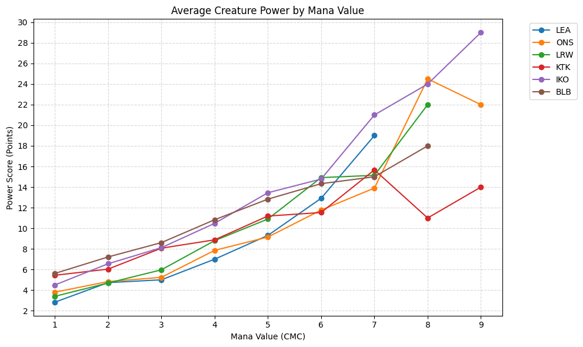

```python
import seaborn as sns

colors = sns.color_palette('tab10', len(sets_upper))

plt.figure(figsize=(10,6))
y_ticks = np.arange(2, 31, 2)

# Plot of the average points value for each creature at every mana value, grouped by set
for i, s in enumerate(sets_upper):
    subset = average_pts[average_pts['set'] == s.lower()]

    plt.plot(
        average_table.index,
        average_table[s],
        marker='o',
        color=colors[i],
        label=s
    )

plt.xlabel('Mana Value (CMC)')
plt.ylabel('Power Score (Points)')
plt.title('Average Creature Power by Mana Value')

plt.yticks(y_ticks)

plt.grid(True, linestyle='--', alpha=0.5)

plt.legend(bbox_to_anchor=(1.05, 1), loc='upper left')

plt.tight_layout()
plt.show()
```

In this chart, we can see the average power score at every mana value for each set. We can notice that the later sets (IKO, BLB) have noticeably higher power scores at the lower mana values than later sets. The variance in power scores at the higher mana values can partially be explained by the fact that there are often very few Creatures at the higher mana values (6+), which skews the data. In some sets, such as LEA, there was only one Creature printed at 7 mana.

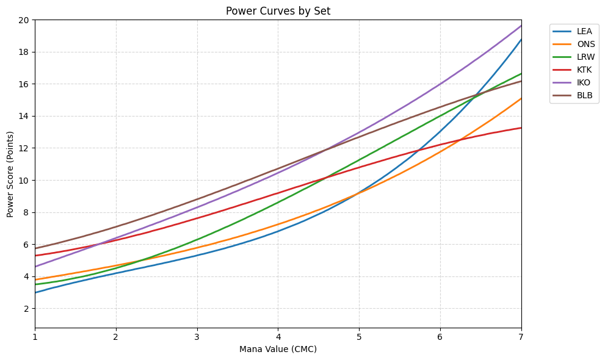

```python
plt.figure(figsize=(10,6))
y_ticks = np.arange(2, 21, 2)

# Plotting the power curves for each set
for i, s in enumerate(sets_upper):
    subset = combined_df[combined_df['set'] == s.lower()]

    plt.plot(
        cmc_plot,
        predictions_plot[s],
        linewidth=2,
        color=colors[i],
        label=s,
    )

plt.xlabel('Mana Value (CMC)')
plt.ylabel('Power Score (Points)')
plt.title('Power Curves by Set')

plt.xlim(1, 7)
plt.ylim(0.8, 20)
plt.yticks(y_ticks)

plt.grid(True, linestyle='--', alpha=0.5)

plt.legend(bbox_to_anchor=(1.05, 1), loc='upper left')

plt.tight_layout()
plt.show()
```

These are curves fit from our model. Similar to our graph of average power scores per set, we see that later sets like IKO and BLB, and to some extent KTK dominate the power scores at lower mana values. The curves become less clear at higher mana values, but this is likely due to two factors:

- small sample sizes skewing the trendlines
- less pronounced power creep at higher mana values

```python
avg_tempo = (
    combined_df
    .groupby(['set','cmc'])['points']
    .mean()
    .reset_index()
)

sets = ['lea', 'ons', 'lrw', 'ktk', 'iko', 'blb']
```

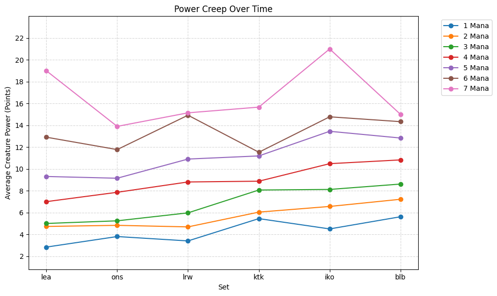

```python
plt.figure(figsize=(10,6))
y_ticks = np.arange(2, 23, 2)

# Plot the change in power creep over time for each mana value and each set
for cmc in cmc_table:
    subset = avg_tempo[avg_tempo['cmc'] == cmc]

    subset = subset.set_index('set').loc[sets].reset_index()

    plt.plot(
        subset['set'],
        subset['points'],
        marker='o',
        label=f"{cmc} Mana"
    )

plt.xlabel('Set')
plt.ylabel('Average Creature Power (Points)')
plt.title('Power Creep Over Time')

plt.ylim(0.8, 24)
plt.yticks(y_ticks)

plt.grid(True, linestyle='--', alpha=0.5)

plt.legend(bbox_to_anchor=(1.05, 1), loc='upper left')

plt.tight_layout()
plt.show()
```

Our last chart showcases how the average power level of creatures changes over time, at each mana value. We can see a noticeable increase at mana values 1-5, with a less clear pattern at mana values 6 and 7, which we have explained previously.

## Predictive Modeling

We can use predictive modeling to help us further evaluate our findings. Since there appears to be a clear delineation between the historical data and the modern game, we can train our model on historical sets (before 2020) and test it on modern sets (2020-onwards).

Analyzing the residuals from our predictive modeling can help us determine if the power levels in the modern game deviate strongly from values predicted by historical design patterns.

```python
# Train on historical sets (1993-2014) and test on later, modern sets (2020-2024)
train_sets = ['lea', 'ons', 'lrw', 'ktk']
test_sets = ['iko', 'blb']

train_df = combined_df[combined_df['set'].isin(train_sets)]
test_df = combined_df[combined_df['set'].isin(test_sets)]

X_train = train_df[['cmc']]
y_train = train_df['points']

X_test = test_df[['cmc']]
y_test = test_df['points']
```

```python
from sklearn.model_selection import cross_val_score

tuning_results = []

# Validate model on our historical data and select the best model
for d in degrees:

    model = make_pipeline(
        PolynomialFeatures(d, include_bias=False),
        LinearRegression()
    )

    rmse_scores = -cross_val_score(
        model, X_train, y_train,
        scoring='neg_root_mean_squared_error',
        cv=5
    )

    mae_scores = -cross_val_score(
        model, X_train, y_train,
        scoring='neg_mean_absolute_error',
        cv=5
    )

    r2_scores = cross_val_score(
        model, X_train, y_train,
        scoring='r2',
        cv=5
    )

    tuning_results.append({
        'degree': d,
        'RMSE': rmse_scores.mean(),
        'MAE': mae_scores.mean(),
        'R2': r2_scores.mean()
    })

print(pd.DataFrame(tuning_results))
```

```
   degree      RMSE       MAE        R2
0       1  2.736183  1.981377  0.457943
1       2  2.721500  1.937907  0.455613
2       3  2.749680  1.953300  0.450574
3       4  2.776257  1.961757  0.443097
```

```python
# Fit the model on our historical sets and test on the modern sets
model = make_pipeline(
    PolynomialFeatures(2, include_bias=False),
    LinearRegression()
)

model.fit(X_train, y_train)

y_pred = model.predict(X_test)

rmse = np.sqrt(mean_squared_error(y_test, y_pred))
mae = mean_absolute_error(y_test, y_pred)
r2 = r2_score(y_test, y_pred)

scores = {
    'RMSE': rmse,
    'MAE': mae,
    'R2': r2
}

print(scores)

# Find the average of residuals in the modern sets to determine drift
test_df = test_df.copy()

test_df['predicted_points'] = y_pred
test_df['residual'] = test_df['points'] - y_pred

average_resid = test_df.groupby('set')['residual'].mean()
print(average_resid)
```

```
{'RMSE': np.float64(3.332762687861721), 'MAE': 2.559176059808934, 'R2': 0.2794974378277588}
set
blb    2.379476
iko    2.258300
Name: residual, dtype: float64
```

We can see from our residuals that two of the modern sets, BLB and IKO, have an average of +2.38 and +2.26 points compared to what would be predicted by historical data. This is in line with the trends we have seen through our previous analysis.

## Conclusions

From our various models, we can determine that broadly speaking, there has been substantial power creep in the 30+ years since the original release of *Magic the Gathering*. This is most noticeable the modern sets, IKO and BLB. BLB in particular is particularly egregious in how much power creep has been present in that set:

- +2.79 at 1 mana
- +2.49 at 2 mana
- +3.61 at 3 mana
- +3.83 at 4 mana

In game terms, this is like having around three extra abilities/keywords at 1 and 2 mana, and around four extra abilities/keywords at 3 and 4 mana.  
This level of power creep is especially problematic at these lower mana values due to the aforementioned relative increase in power. If a Creature at one mana is historically allowed one or two abilities, for the same or similar power/toughness values, the modern game is essentially increasing its power by 50-100%. This effect falls off as you increase the mana value, due to having a higher base power score, but these effects are still noticeable at 3, 4, and 5 mana. Beyond this, variance and the floor for power scorces is high enough that this effect is mitigated, but still worth observing.

## Challenges and Limitations

- power
- toughness
- mana value
- number of abilities
- number of keywords
- triggers
- card draw
- direct damage
- removal
- global effects

Our power score system collapsed these features into one number, which means that our model ultimately had low explanatory power due to losing most of that variance.

As stated previously, there is more nuance and complexity for Creature abilities than our criteria could reasonably evaluate. While our criteria was consistent, the simple nature of the scoring meant that it may have under- or over-valued certain aspects of card text when evaluting Creatures. This is not necessarily a bad thing, since we are not interested in evaluating how powerful the cards truly are. Rather, we are looking at the mechanical value each card contains and how that has changed over time. Still, we can improve the evaluation criteria to further improve consistency. In particular, treating downsides as 0 is likely not an ideal solution.

## Future Work and Improvements

The most straightforward improvement to our model would be to expand the feature space. Instead of just using mana value as a collapsed version of our criteria, we could add structured features to our data set that we already cover in our criteria. Additional improvements include binary keyword features and rules-based oracle text detection.

From this, we could more easily answer the following research question:

**How much does each component of a Creature card actually affect its power score?**

By quantifying this metric, we can then get a clearer sense of what factors influence power creep the most, and perhaps make prescriptive suggestions towards how to mitigate or avoid the negative effects of power creep while still allowing for interesting designs and player excitement.

[figure not shown]